# Topic 20

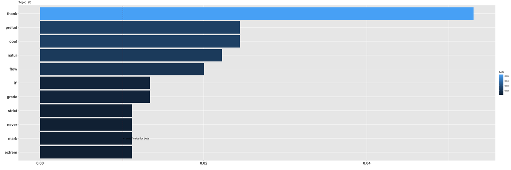

On interpreting beta: the term has a beta probability of being generated from the particular topic.

Values below are gamma : An estimated proportion of words from that document that are generated from that topic.

**Text Record Number: 1045** gamma: 13 % likelihood of this document (based on its words) in this topic

**This is prelude 1 from Bach’s Six Little Preludes.

I’m teaching myself to play piano again after a roughly 15 year break. I was never particularly advanced (I think I learned up to grade 4 or 5 Trinity College exams before I stopped).

Anyway, I either never encountered this back then or don’t remember what it means! I don’t even know what this mark is called so I can’t Google it.

Any help - either with the name of this mark or how to play the left hand here - would be much appreciated!**

**Text Record Number: 1277** gamma: 13 % likelihood of this document (based on its words) in this topic

**Though I’m a relative newbie to the piano, I have a teacher and take a lesson each week, and what’s nice about playing with my teacher looking over my shoulder is she can tell me when I hit a wrong note (among many other things), but when I play at home, until I know a piece pretty well, I can’t always tell if I play a wrong note or botch a chord. And sometimes I think I’m playing the wrong note or chord but it turns out to be right. So I’m wondering: Are there any piano apps that let me add my own scores to the library the app comes with? Create my own library whose pieces I can play in the same way and with the same features as the pieces I can play when I subscribe to the app and get access to its library?

It would be great if I could just input a score, say from MuseScore. For example, right now I am learning the first four lines/16 measures of [Ode To Joy, from 8notes.com](https://www.8notes.com/scores/435.asp), and I’d love to be able play it in an app that’ll stop or squawk at me when I hit a wrong key(s).

At the risk of looking a gift horse in the mouth, what would be really great would be if it let me add my own fingering/comments etc, but now I may have gotten into specifying an app that doesn’t exist. (Yet?)

Thanks in advance for any help anyone can give.**

**Text Record Number: 1361** gamma: 13 % likelihood of this document (based on its words) in this topic

**I know someone posted a similar question recently asking for simple/intermediate piano/violin duets, but I’m looking for something super simple. Like, if you had kids in early elementary school who were learning the piano and violin, and you wanted them to do a duet, what would you give them? Are there any books I can get something out of?

For context, I am an experienced piano player and my friend is an experienced violin player. As a fun summer project, we are teaching each other our instruments and we want to do a duet on our new instruments before we both move away in September. So by the time we play this duet, she will have two months of experience on the piano and I will have two months of experience on the violin.**

**Text Record Number: 1075** gamma: 13 % likelihood of this document (based on its words) in this topic

**Thank you for the great advice! I listened to that piece and it seemed a bit more in reach for me and it was a very nice piece as well. I think I’ll start with the prelude and practice polyrythm at the same time to maybe make me more ready for the nocturne! :) Thanks!**

**Text Record Number: 1409** gamma: 13 % likelihood of this document (based on its words) in this topic

**Hey guys! I’m a piano newby, restarted in February and wanted to get some feedback on my progress so far.

I did take piano lessons when i was a kid for approx 3-4y once a week, but i must say i wasn’t motivated enough and my teacher wasn’t the best, so i had only gotten so far as to play chords in my left hand and melodies in my right. Never really got to play fully two handed. After about 20y i decided to get into piano again, so here i am :)

I’ve been practicing 30min-1h everyday (except some occasional times) with the pianoforall course material. I’ve also been experimenting learning some songs from youtube (learned cardigan from taylor swift and roses of may from final fantasy OST).

I recently played the first 30second of river flows in you and thought i might use it for getting feedback. Still find it hard to play both handed, but it’s getting better. Any advise is appreciated! Thanks! [video](https://photos.app.goo.gl/SWTS5L8Quj3YRjt66)**

**Text Record Number: 328** gamma: 13 % likelihood of this document (based on its words) in this topic

**Currently working on prelude BWV 847 in C minor, I’m at an intermediate level so I’m just looking for something more challenging that can improve my technique in general. Regarding the terminology I can understand both it’s not a problem**

**Text Record Number: 63** gamma: 13 % likelihood of this document (based on its words) in this topic

**Generally, it helps a lot with technique (not sure about back pain) to sit on the front half of the piano bench, so you might try scooting the chair back and only sitting on the front of it. That will push more weight into your feet, which is what you want. Personally, chair looks slightly lower than the general advisement: your elbows are slightly lower than the top knuckles on your hand/your wrist; although it could be the angle of the camera too. But, chair/keyboard height is up to each individual. Some like a lower stool. Over the years, I’ve lowered mine more and more.

Hard to tell from just a photo where tension might be. For most students, it’s the shoulders. Try to be aware of if you’re lifting your arms up (via the shoulders) and playing by pressing down with just your fingertips or if you’re letting the weight of your arms sink into the keys and do most of the work. That’s something I see with a lot of students is that they have a tendency to hold up their arms, making them hover more over the keys, which creates more work for them and can cause tension in the shoulders and upper back. If that is the case, a good exercise is to kind of lock your fingers and just do some warmups or slow playing using only the weight of your upper body. That’s where a slightly taller stool/chair would be helpful because you’ll have more weight over the keyboard.

I hope some of this helps. But yeah, experiment with weight and chair/keyboard height, and feel free to reach out any time with questions.**